# HW03 - Stat 133, Fall 2016

Prof. Sanchez LAB 204

Xuanpei Ouyang

The purpose of this assignment is to write simple functions, as well as practicing using conditionals and loops in R. Please turn in a physical copy of the knitted html file during lab, and submit both your `.Rmd` and `.html` files to bCourses. Due Friday Oct-07.

## Area of a circle

For a given circle of radius $r$, the area $A$ is:
$$A = \pi r^2$$

Write a function `circle_area()` that calculates the area of a circle. This function must take one argument `radius`. Give `radius` a default value of 1. The function should `stop()` if `radius` is negative. In the code chunk options, please include `error = TRUE` so that you don’t get an error when knitting the file.

```r
# your circle_area() function

# function for calculating the area of a circle
# intput: radius, numeric value for the radius of the circle
# output: the area of the circle
circle_area = function(radius = 1) {
  if(radius < 0){
    stop("radius cannot be negative")
  }
  area = pi*radius^2
  return(area)
}
```

Test your function:

```r
circle_area()
```

```
## [1] 3.141593
```

```r
circle_area(radius = 3)
```

```
## [1] 28.27433
```

```r
circle_area(radius = -2)
```

```
## Error in circle_area(radius = -2): radius cannot be negative
```

## Area of a cylinder

For a given cylinder of radius $r$ and height $h$ the area $A$ is:
$$A = 2 \pi r h + 2 \pi r^2$$

Notice that the formula of the area of a cylinder includes the area of a circle: $\pi r^2$. Write a function `cyl_area()`, that calls `circle_area()`, to compute the area of a cylinder.

This function must take two arguments: `radius` and `height`. Give both arguments a default value of 1. In addition, the function should stop if any of `radius` or `height` are negative.

```r
# your cyl_area() function

# function for calculating the area of a cylinder
# intput: radius, the radius of the cylinder
#         height, the height of the cylinder
# output: the area of the cylinder
cyl_area = function(radius = 1, height = 1) {
  if(radius < 0 || height < 0 ){
    stop("radius and height cannot be negative")
  }
  lower_half = 2*circle_area(radius)
  upper_half = 2*pi*radius*height
  area = lower_half + upper_half
  return(area)
}
```

Test your function

```r
cyl_area()
```

```
## [1] 12.56637
```

```r
cyl_area(radius = 2, height = 3)
```

```
## [1] 62.83185
```

```r
cyl_area(radius = -2, height = 1)
```

```
## Error in cyl_area(radius = -2, height = 1): radius and height cannot be negative
```

```r
cyl_area(radius = 2, height = -1)
```

```
## Error in cyl_area(radius = 2, height = -1): radius and height cannot be negative
```

```r
cyl_area(radius = -2, height = -1)
```

```
## Error in cyl_area(radius = -2, height = -1): radius and height cannot be negative
```

## Volume of a cylinder

For a given cylinder of radius $r$ and height $h$ the volume $V$ is:
$$V = \pi r^2 h$$

Write a function `cyl_volume()`, that calls `circle_area()`, to compute the volume of a cylinder. This function must take two arguments: `radius` and `height`. Give both arguments a default value of 1.

```r
# your cyl_volume() function

# function for calculating the volumne of a cylinder
# intput: radius, the radius of the cylinder
#         height, the height of the cylinder
# output: the volumne of the cylinder
cyl_volume = function(radius = 1, height = 1) {
  if(radius < 0 || height < 0 ){
    stop("radius and height cannot be negative")
  }
  volume = circle_area(radius) * height
  return(volume)
}
```

Test your function:

```r
cyl_volume()
```

```
## [1] 3.141593
```

```r
cyl_volume(radius = 3, height = 10)
```

```
## [1] 282.7433
```

```r
cyl_volume(height = 10, radius = 3)
```

```
## [1] 282.7433
```

## Currency Converter

Consider the exchange rates of one US dollar for the following currencies (source: XE currency table US dollar, 09-20-2016):

| Currency | name | rate |
| --- | --- | --- |
| US dollar | `dollar` | 1.00 |
| Euro | `euro` | 0.89 |
| British pound | `pound` | 0.77 |
| Japanese yen | `yen` | 101.69 |
| Chinese yuan | `yuan` | 6.67 |
| South Korean Won | `won` | 1118.21 |
| Indian rupee | `rupee` | 66.98 |
| Mexican peso | `peso` | 19.82 |
| Brazilian real | `real` | 3.25 |

Write a function `exchange()` that converts from one currency to another. This function takes three arguments:

- `amount` is a positive numeric input
- `from` is a character string indicating the name of a currency
- `to` is a character string indicating the name of a currency

Give these arguments default values of `amount = 1`, `from = "dollar"`, and `to = "euro"`. Inside `exchange()` you must declare a named vector with the given exchange rates:

```r
# function for converting between different currency
# intput: amount, a positive numeric value for amount of money to convert
#         from, a characater string indicating the name of a currency
#         to, a character string indicating the name of a currency
# output: a numeric vector
exchange <- function(amount = 1, from = "dollar", to = "euro") {

  # vector of dollar exchange rates
  x <- c(
    dollar = 1,
    euro = 0.89,
    pound = 0.77,
    yen = 101.69,
    yuan = 6.67,
    won = 1118.21,
    rupee = 66.98,
    peso = 19.82,
    real = 3.25)

  # convert the from currency to US dollor first
  from_rate = x[from]
  to_rate = x[to]
  # compute the converted amount in to currency
  convert_amount = amount * (to_rate / from_rate)
  return(convert_amount)
}
```

- You can use any control flow structure: `if-else`, `switch()`, `for` loops, `while`, `repeat`.
- You can use any data structures inside `exchange()`: vectors, matrices, data frames, lists, etc.
- The output must be a numeric vector

Test your `exchange()` function with:

```r
exchange()
```

```
## euro
## 0.89
```

```r
exchange(amount = 10, from = 'euro', to = 'peso')
```

```
##     peso
## 222.6966
```

```r
exchange(amount = 20, from = 'yuan', to = 'pound')
```

```
##    pound
## 2.308846
```

```r
exchange(amount = 30, from = 'rupee', to = 'won')
```

```
##      won
## 500.8405
```

## Two Given Points

Let $p_1$ and $p_2$ be two points with two coordinates: $p_1 = (x_1, y_1)$ and $p_2 = (x_2, y_2)$.

The distance $d$ between two points can be calculated with the formula:
$$d = \sqrt{(x_2 - x_2)^2 + (y_2 - y_1)^2}$$

The midpoint of the line segment between $p_1$ and $p_2$ can be found as:
$$p = \left( \frac{x_1 + x_2}{2}, \frac{y_1 + y_2}{2} \right)$$

The intercept $a$ and the slope $b$ of the line $y = a + bx$ connecting two points $p_1$ and $p_2$ can be found as:
$$b = \frac{y_2 - y_1}{x_2 - x_1}, \quad a = y_1 - b x_1$$

#### Distance

Write a function `find_distance()` that returns the distance between two given points. You should be able to call the function like this:

```r
# coordinates for point-1 and point-2
p1 <- c(0, 0)
p2 <- c(1, 1)

find_distance(p1, p2)
```

Your function:

```r
# your find_distance() function

# function for computing the distance between two given points
# input: p1, numeric vector with length 2 for coordinate of first point
#        p2, numeric vector with length 2 for coordinate of second point
# output: the distance between the two points
find_distance = function(p1, p2) {
  point_sum = sum( (p2 - p1)^2 )
  distance = sqrt(point_sum)
  return(distance)
}
```

Test your `find_distance()` function with:

```r
# NOTE: Uncomment the following lines and then knit this file to check your function is working as required

p1 <- c(1, 10)
p2 <- c(10, 20)
find_distance(p1, p2)
```

```
## [1] 13.45362
```

#### Midpoint

Write a function `find_midpoint()` that returns the midpoint between two given points. You should be able to call the function like this:

```r
p1 <- c(0, 0)
p2 <- c(1, 1)

find_midpoint(p1, p2)
```

Your function:

```r
# your find_midpoint() function

# function for computing the midpoint between two given points
# input: p1, numeric vector with length 2 for coordinate of first point
#        p2, numeric vector with length 2 for coordinate of second point
# output: the midpoint between the two points
find_midpoint = function(p1, p2) {
  midpoint = (p1 + p2) / 2
  return(midpoint)
}
```

Test your `find_midpoint()` function with:

```r
# NOTE: Uncomment the following lines and then knit this file to check your function is working as required

p1 <- c(1, 10)
p2 <- c(10, 20)
find_midpoint(p1, p2)
```

```
## [1]  5.5 15.0
```

#### Slope

Write a function `find_slope()` that returns the slope of the line connecting two given points. You should be able to call the function like this:

```r
p1 <- c(0, 0)
p2 <- c(1, 1)

find_slope(p1, p2)
```

Your function:

```r
# your find_slope() function

# function for computing the slope between two given points
# input: p1, numeric vector with length 2 for coordinate of first point
#        p2, numeric vector with length 2 for coordinate of second point
# output: the slope between the two points
find_slope = function(p1, p2) {
  diff = p2 - p1
  slope = diff[2]/diff[1]
  return(slope)
}
```

Test your `find_slope()` function with:

```r
# NOTE: Uncomment the following lines and then knit this file to check your function is working as required

p1 <- c(1, 10)
p2 <- c(10, 20)
find_slope(p1, p2)
```

```
## [1] 1.111111
```

#### Intercept

Write a function `find_intercept()` that returns the intercept of the line connecting two given points. This function must internally use `find_slope()`

```r
p1 <- c(0, 0)
p2 <- c(1, 1)

find_intercept(p1, p2)
```

Your function:

```r
# your find_intercept() function

# function for computing the intercept of the line between two given points
# input: p1, numeric vector with length 2 for coordinate of first point
#        p2, numeric vector with length 2 for coordinate of second point
# output: the intercept of the line between the two points
find_intercept = function(p1, p2) {
  slope = find_slope(p1, p2)
  intercept = p1[2] - slope * p1[1]
  return(intercept)
}
```

Test your `find_intercept()` function with:

```r
# NOTE: Uncomment the following lines and then knit this file to check your function is working as required

p1 <- c(1, 10)
p2 <- c(10, 20)
find_intercept(p1, p2)
```

```
## [1] 8.888889
```

#### Line

Write a function `find_line()`. This function must use `find_slope()` and `find_intercept()`. The output should be a list with two named elements: `"intercept"` and `"slope"`, Here is how you should be able to use `find_line()`:

```r
p1 <- c(0, 0)
p2 <- c(1, 1)

eq <- find_line(p1, p2)
eq$intercept
eq$slope
```

Your function:

```r
# your find_line() function

# function for computing the line between two given points
# input: p1, numeric vector with length 2 for the coordinate of first point
#        p2, numeric vector with length 2 for the coordinate of second point
# output: the line between the two points
find_line = function(p1, p2) {

  point_line = list(
    slope = find_slope(p1, p2),
    intercept = find_intercept(p1, p2))
  return(point_line)
}
```

Test your `find_line()` function with:

```r
# NOTE: Uncomment the following lines and then knit this file to check your function is working as required

p1 <- c(1, 10)
p2 <- c(10, 20)
eq <- find_line(p1, p2)
eq$intercept
```

```
## [1] 8.888889
```

```r
eq$slope
```

```
## [1] 1.111111
```

#### Information about two given points

Once you have the functions `find_distance()`, `find_midpoint()`, and `find_line()`, write an overall function called `info_points()` that returns a list with the distance, the midpoint, and the line’s slope and intercept terms. Here is how you should be able to use `info_points()`:

```r
p1 <- c(-2, 4)
p2 <- c(1, 2)

results <- info_points(p1, p2)
results$distance
results$midpoint
results$intercept
results$slope
```

Your function:

```r
# your info_points() function

# function for computing the distance, midpoint and line between two points
# input: p1, numeric vector with length 2 for the coordinate of first point
#        p2, numeric vector with length 2 for the coordinate of second point
# output: the data frame containing the info about two points
info_points = function(p1, p2) {

  line_info = find_line(p1, p2)

  info_df = list(
    distance = find_distance(p1, p2),
    midpoint = find_midpoint(p1, p2),
    intercept = line_info$intercept,
    slope = line_info$slope
  )
  return(info_df)
}
```

Test your `find_line()` function with:

```r
# NOTE: Uncomment the following lines and then knit this file to check your function is working as required

p1 <- c(1, 10)
p2 <- c(10, 20)

results <- info_points(p1, p2)
results$distance
```

```
## [1] 13.45362
```

```r
results$midpoint
```

```
## [1]  5.5 15.0
```

```r
results$intercept
```

```
## [1] 8.888889
```

```r
results$slope
```

```
## [1] 1.111111
```

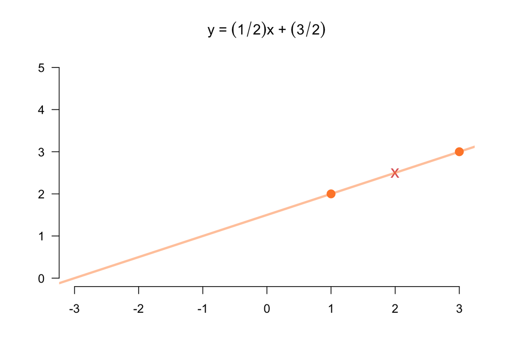

```r
# change these points and pass them to info_points()
p1 <- c(1, 2)
p2 <- c(3, 3)

results = info_points(p1, p2)

plot.new()
# depending on your chosen points you may have to set different limits
plot.window(xlim = c(-3, 3), ylim = c(0, 5))
axis(side = 1)
axis(side = 2, las = 1)
points(p1[1], p1[2], cex = 1.5, col = "#FF8834", pch = 19)
points(p2[1], p2[2], cex = 1.5, col = "#FF8834", pch = 19)

# midpoint (here you should use the midpoint outputs of your function)
points(results$midpoint[1], results$midpoint[2], cex = 1.5, pch = "x", col = "#E16868")

# slope and intercept (here you should use the outputs of your function)
abline(a = results$intercept, b = results$slope, col = "#FF883477", lwd = 3)

title(main = expression(paste(y, ' = ', (1/2) * x, ' + ', (3/2))))
```